# Assessment 3

Veronika Varaksina s4646146

6/11/2021

### Introduction

In this report I will cover the data analysis of the IKEA online store data set. This data set being used for this research has been created through web scraping of the IKEA Saudi Arabian website in 2020. The data set consists of 2961 rows and 13 columns. Every row represents a piece of furniture and 13 variables describe it in detail. Through this report readers will understand the connections and trends between observations and variables, and how application of modeling tools can benefit the company. The aim of this report is to answer business decision-making questions by utilizing the data set:

- What affects the price of furniture?
- Based on what factors IKEA furniture is on discount?
- How to predict the category of the furniture?

The structure of the report includes data cleaning and wrangling, data visualization, data modeling, model performance and model application.

### Data wrangling

The data analysis is viewed as “the result of a number of data processing steps where each step increases the value of the data” (de Jonge and van der Loo, 2021). That statement refers to the fact that the analysis starts with the raw state of the data and ends with data being a formatted output. The raw data in most cases includes missing values, wrong types of data, etc. After going through the steps of the data cleaning process, the data becomes technically correct and consistent. At this point data is ready for the analysis.

The first step of the data cleaning process is removing columns that are not necessary in the analysis and don’t hold any statistical value. Those columns include:

- id column (the ids are repeating, they are not unique numbers, representing each piece of furniture).
- link (it does not hold any statistical value).
- short description (this column is not formatted and cannot be analyzed, as the value differs drastically).

```r
tidyikea <- ikea %>%
  select(-X1, -link, -short_description, -item_id)
```

In order to use full functionality of R, some character type variables have to be changed to a factor. It is usually done for columns that have smaller amounts of unique values. This step of changing the type of variable is called coercion. The variables that went under coercion include: category, color availability, name, online availability and designers.

```r
tidyikea$other_colors <- tolower(tidyikea$other_colors)
tidyikea <- tidyikea %>%
  mutate(category = as_factor(category),
         other_colors = as_factor(other_colors),
         name = as_factor(name),
         sellable_online = as_factor(sellable_online))
```

“A missing value, represented by NA in R, is a placeholder for a datum of which the type is known but its value isn’t”(de Jonge and van der Loo, 2021). The analysis can not be performed on the data that is missing. Therefore, for analytics and modeling purposes “na” rows will be omitted in this report. In other cases a chosen value can be placed instead of “na”, but in this data set most of the na values appear in variables such as height, width and depth. As neither of those parameters of furniture can be possibly equal to zero or only one, omitting these rows is absolutely necessary for data cleaning.

```r
tidyikea <- na.omit(tidyikea)
```

One of the variables in the data set represents the current price of furniture pieces in Saudi Riyals. For accessibility purposes prices have to change from Saudi Riyals to Australian Dollars. That way the general audience will comprehend the price formation of IKEA products better. In order to achieve that, the price has to be multiplied by the currency rate that is 0.34 at the time of this research.

```r
tidyikea <- tidyikea %>%
  mutate(price = price * 0.34)
```

The character data is difficult to process, because the same data can be written in similar ways. “Messy” text strings have to be normalized and matched in order to make the variable consistent and suitable for analysis. “String normalization techniques are aimed at transforming a variety of strings to a smaller set of string values which are more easily processed”(de Jonge and van der Loo, 2021). Designer names can be considered “messy” data. There are four types of data formats present in this variable:

1. The designer’s name alone is “Karl Malmvall”.
2. The designers name after the company name “IKEA of Sweden/Karl Malmvall”.
3. The designer was named before the company name “Henrik Preutz/IKEA of Sweden”.
4. The designer’s name is the company name. In this case the item has no designated designer.

After string coding the values of the variable by either the designer name or name of a company. These steps are essential for further analysis.

```r
tidyikea$designer <- gsub("IKEA of Sweden","", tidyikea$designer)
tidyikea$designer <- gsub("/"," ", tidyikea$designer)
tidyikea <- tidyikea %>%
  mutate(designer = str_trim(designer))
tidyikea <- tidyikea %>%
  mutate_all(na_if,"")
tidyikea <- tidyikea %>%
  mutate(designer = replace_na(designer, "IKEA design"),
         designer = as_factor(designer))
```

Adding meaningful columns is a part of data wrangling. In order to be able to compare and analyze sizes of diverse IKEA furniture, variables like height, depth and width have to be simplified to one number or factors. By multiplying height, depth and width and saving it in a new column of the data frame named volume, all furniture pieces now have a size parameter that is counted by cubic centimeters. The volume of furniture can be divided into three groups: small, medium and large.

Another variable that has to be changed to a factor type is the old price. The percent of the discount remains the same across different types of furniture and is irrelevant to the research. Instead of a number, data was manipulated to showcase if an item is on discount or is it sold at full price. Both discounts and online availability were changed from boolean type to a factor type.

```r
tidyikea <- tidyikea %>%
  mutate(volume_cm3 = depth * height * width,
         size_type = cut_number(volume_cm3, 3, labels = c("small", "medium", "big")),
         discounted = parse_number(old_price))
tidyikea <- tidyikea %>%
  select(-old_price)
tidyikea$discounted[tidyikea$discounted > 0] <- "yes"
tidyikea$discounted[is.na(tidyikea$discounted)] <- "no"
tidyikea <- tidyikea %>%
  mutate(discounted = as_factor(discounted))
tidyikea <- tidyikea %>%
  mutate(sellable_online = as.character(sellable_online))
tidyikea$sellable_online[tidyikea$sellable_online == "TRUE"] <- "yes"
tidyikea$sellable_online[tidyikea$sellable_online == "FALSE"] <- "no"
tidyikea <- tidyikea %>%
  mutate(sellable_online = as_factor(sellable_online))
```

After data cleaning and wrangling, a quick overview of the data frame can be done through the “skimr” package. Function “skim” dispatches “a different set of summary functions based on the types of columns in the data frame”(Waring, 2021). Overview describes the data frame as seven factor variables and five numeric variables.

```r
skim(tidyikea)
```

Data summary

| Name | tidyikea |
| --- | --- |
| Number of rows | 1899 |
| Number of columns | 12 |
| _______________________ |  |
| Column type frequency: |  |
| factor | 7 |
| numeric | 5 |
| ________________________ |  |
| Group variables | None |

**Variable type: factor**

| skim_variable | n_missing | complete_rate | ordered | n_unique | top_counts |
| --- | --- | --- | --- | --- | --- |
| name | 0 | 1 | FALSE | 289 | BES: 131, PAX: 101, EKE: 57, TRO: 54 |
| category | 0 | 1 | FALSE | 17 | Boo: 375, Sof: 223, Cha: 213, Cab: 199 |
| sellable_online | 0 | 1 | FALSE | 2 | yes: 1886, no: 13 |
| other_colors | 0 | 1 | FALSE | 2 | no: 988, yes: 911 |
| designer | 0 | 1 | FALSE | 140 | IKE: 427, Ehl: 175, Jon: 136, Ola: 127 |
| size_type | 0 | 1 | FALSE | 3 | sma: 634, big: 633, med: 632 |
| discounted | 0 | 1 | FALSE | 2 | no: 1541, yes: 358 |

**Variable type: numeric**

| skim_variable | n_missing | complete_rate | mean | sd | p0 | p25 | p50 | p75 | p100 | hist |
| --- | --- | --- | --- | --- | --- | --- | --- | --- | --- | --- |
| price | 0 | 1 | 415.01 | 483.51 | 2.04 | 100.3 | 231.2 | 540.26 | 3258.9 | ▇▁▁▁▁ |
| depth | 0 | 1 | 56.16 | 30.58 | 1.00 | 40.0 | 47.0 | 60.00 | 257.0 | ▇▃▁▁▁ |
| height | 0 | 1 | 113.11 | 62.75 | 2.00 | 71.0 | 92.0 | 171.00 | 301.0 | ▃▇▂▃▁ |
| width | 0 | 1 | 119.75 | 77.52 | 2.00 | 60.0 | 93.0 | 161.50 | 420.0 | ▇▆▃▁▁ |
| volume_cm3 | 0 | 1 | 910690.07 | 1110359.29 | 40.00 | 202656.0 | 467200.0 | 1299817.50 | 13629000.0 | ▇▁▁▁▁ |

### Data visualization

Data visualization is a “method of representing data in a graphical format, useful both for communicating results and exploring data sets” (Boehmke, 2016). By giving the data a visual context through graphs, it makes it easier to identify trends, patterns and outliers within the data set. There are many methods and approaches that are used for delivering the information to an audience through data visualization. In this report, using the ggplot2 package, main trends and patterns of the data set are reflected as graphs.

The IKEA furniture data set contains prices for products between seventeen different categories. The distribution of the prices amongst the categories does not give a clear depiction of what affects the products costs. Thus, in the first part of data visualization the question of price formation is investigated through looking at each individual variable and distinguishing the type of relationship it has with the price.

The most evident price formation factor for IKEA furniture is the sizing. The relationship between the two variables (size & price) can be described as a positive correlation. Bigger items, like bed and sofas, are significantly higher in price than shelves and chairs.

However, some categories, like “sofas & armchairs”, on average cost more than products from the similar size categories like “chests & drawers”. That leads to a conclusion, that even though size is a significant factor in defining the price, the type of an item is also considered by IKEA when deciding the price.

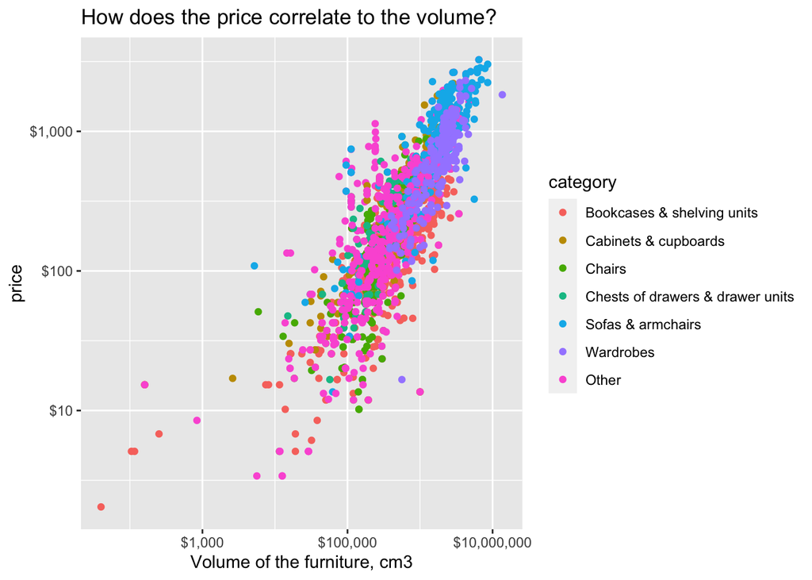

```r
tidyikea %>%
  mutate(category = fct_lump(category, 6)) %>%
  ggplot(aes(volume_cm3, price, color = category)) +
  geom_point() +
  scale_x_log10(label = dollar) +
  scale_y_log10(label = dollar) +
  labs(x = "Volume of the furniture, cm3",
       title = "How does the price correlate to the volume?")
```

Data visualization can be used to showcase the distribution of prices which leads to the conclusion that IKEA prioritizes selling higher priced products online. Items that are not available online are usually from the kids furniture category and are generally cheaper on average. There could be two possible conclusions made based on that fact: it is unprofitable for IKEA to sell online and deliver small low priced items due to logistics and organizational costs. Alternatively this choice was made based on the fact that the IKEA kids section includes toys and other minuscule items, that are usually chosen by kids at the store and not purchases that adults would make shopping on the webstore. However, only 1% of IKEA products are not being sold online. When it comes to analysing the price formation, it is more likely that availability online will not affect the final price of the product, as the number of items that are not sold on the website is miniscule.

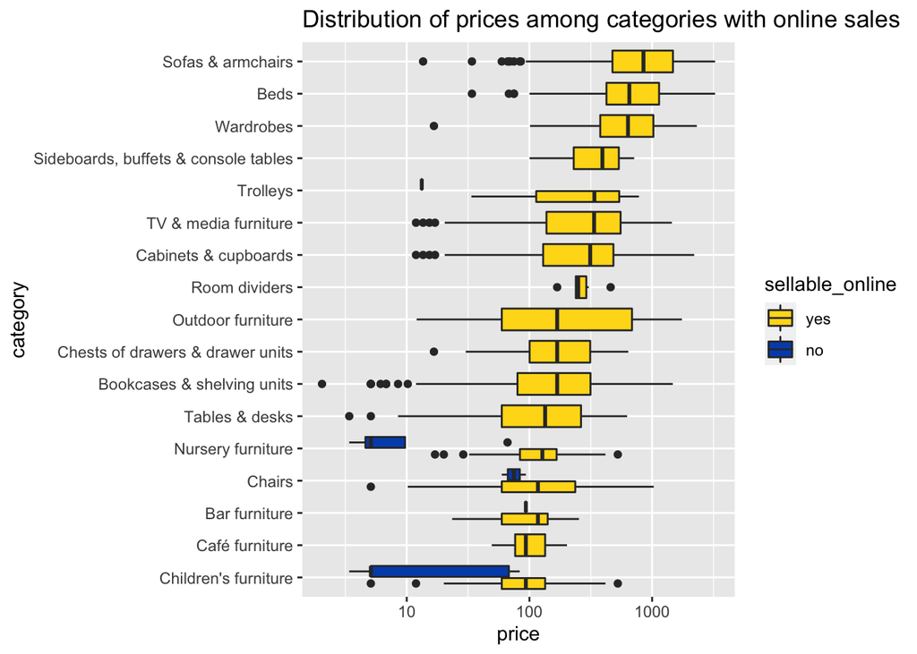

```r
tidyikea %>%
  mutate(category = fct_reorder(category, price)) %>%
  ggplot(aes(price, category, fill = sellable_online)) +
  geom_boxplot() +
  scale_fill_manual(values=c('#FFDA1A', '#0051BA')) +
  scale_x_log10() +
  labs(title = "Distribution of prices among categories with online sales")
```

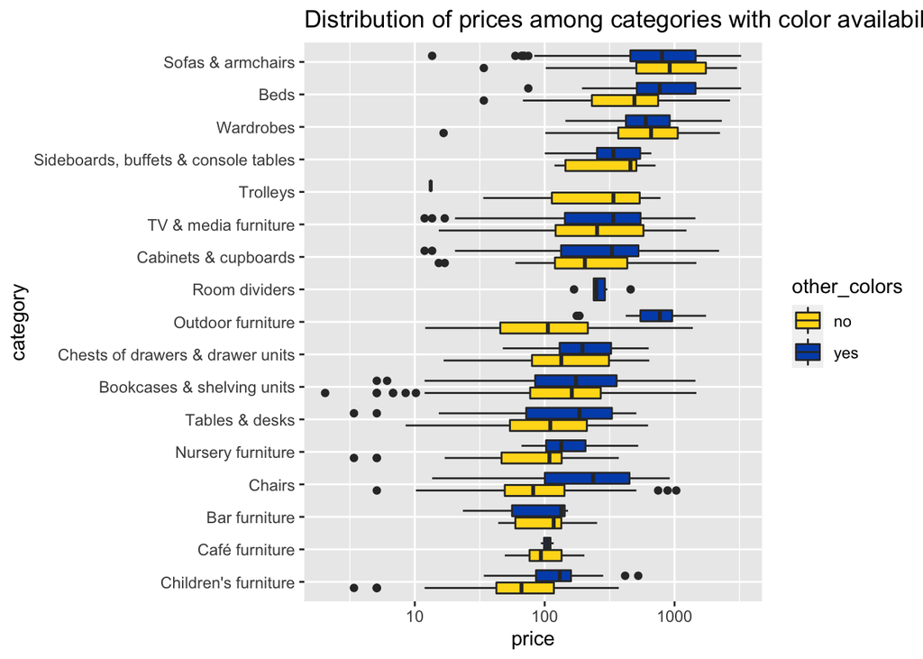

```r
tidyikea %>%
  mutate(category = fct_reorder(category, price)) %>%
  ggplot(aes(price, category, fill = other_colors)) +
  geom_boxplot() +
  scale_fill_manual(values=c('#FFDA1A', '#0051BA')) +
  scale_x_log10() +
  labs(title = "Distribution of prices among categories with color availability")
```

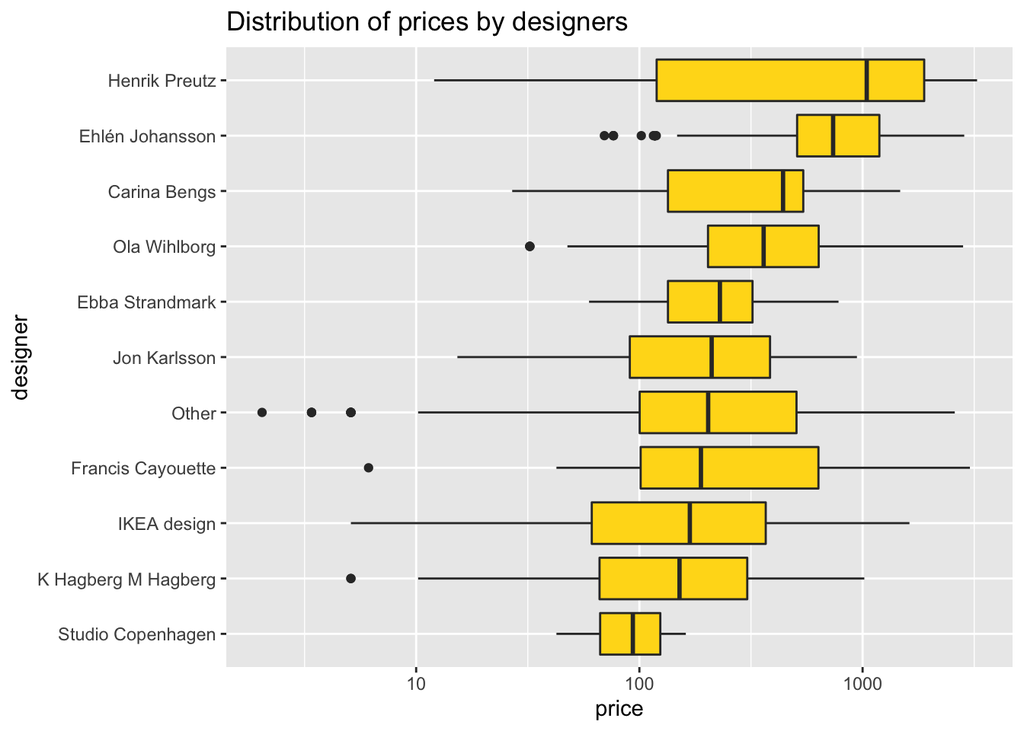

```r
tidyikea %>%
  mutate(designer = fct_lump(designer, 10)) %>%
  mutate(designer = fct_reorder(designer, price)) %>%
  ggplot(aes(price, designer)) +
  geom_boxplot(fill='#FFDA1A') +
  scale_x_log10() +
  labs(title = "Distribution of prices by designers")
```

To summarise, when it comes to the formation of price the most evident coefficients are size, category, designer, color availability.

In the second part of the data visualization process the question of discounted products will be analyzed. Almost 20% of IKEA furniture in the data set is listed as “on sale”. Whereas the size of a discount is relatively the same from item to item, the motivation for putting the item on sale is what is relevant in this scenario. This could be the collection, the designer or the size of the furniture that ultimately leads an item to ending up within the sales collection.

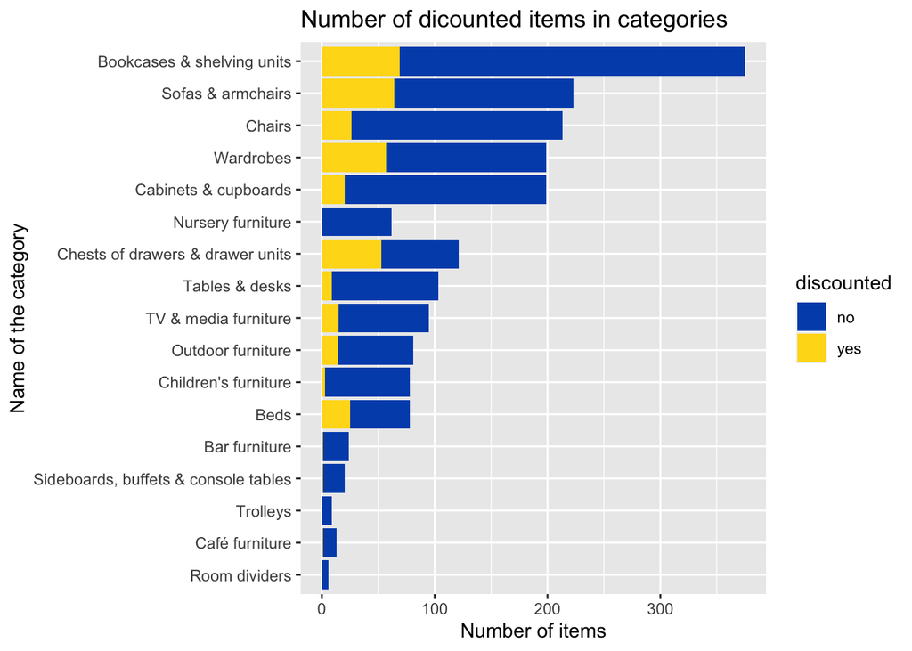

```r
tidyikea %>%
  count(category, discounted, sort = TRUE) %>%
  mutate(category = fct_reorder(category, n)) %>%
  ggplot(aes(n, category, fill = discounted)) +
  geom_col() +
  scale_fill_manual(values=c('#0051BA', '#FFDA1A')) +
  labs(x = "Number of items",
       y = "Name of the category",
       title = "Number of dicounted items in categories")
```

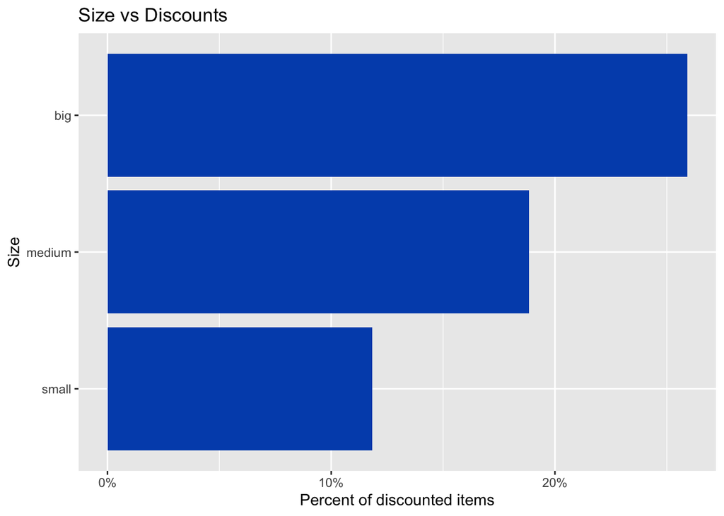

```r
tidyikea %>%
  count(size_type, discounted, sort = TRUE) %>%
  group_by(size_type) %>%
  mutate(n_total = sum(n)) %>%
  ungroup() %>%
  mutate(percent_disc = n / n_total) %>%
  mutate(size_type = fct_reorder(size_type, percent_disc)) %>%
  filter(discounted == "yes") %>%
  ggplot(aes(percent_disc, size_type)) +
  geom_col(fill='#0051BA') +
  scale_x_continuous(labels = percent_format()) +
  labs(x = "Percent of discounted items",
       y = "Size",
       title = "Size vs Discounts")
```

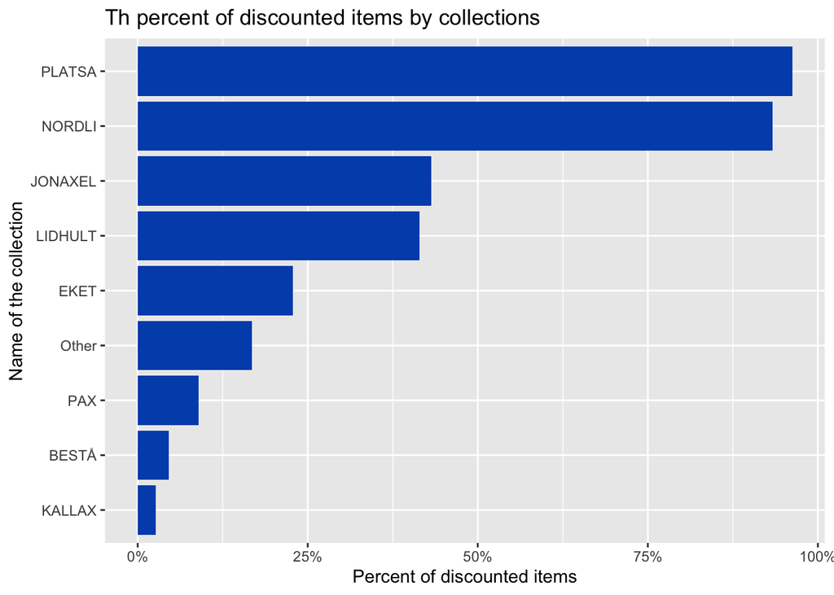

```r
tidyikea %>%
  mutate(name = fct_lump(name, 12)) %>%
  count(name, discounted, sort = TRUE) %>%
  group_by(name) %>%
  mutate(n_total = sum(n)) %>%
  ungroup() %>%
  mutate(percent_disc = n / n_total) %>%
  filter(discounted == "yes") %>%
  mutate(name = fct_reorder(name, percent_disc)) %>%
  ggplot(aes(percent_disc, name)) +
  geom_col(fill='#0051BA') +
  scale_x_continuous(labels = percent_format()) +
  labs(x = "Percent of discounted items",
       y = "Name of the collection",
       title = "Th percent of discounted items by collections")
```

### Modelling

“All models are wrong, but some are useful” (Toomey, n.d.). The goal of the model is to provide a simple summary on a complicated event, process or observation.The model allows us to better understand the causations and outcomes of certain events. In the case of the IKEA furniture data set, three models can be created in order to answer the business questions we raised in the beginning of this report:

- Regression: predicting the sales price of a new item.
- Classification: predicting if an item will be discounted or not.
- Classification: predicting the category of a new item.

In the report, modelling was completed through these steps:

- Splitting data into training and testing sets, all of the models will be split in the 70/30 proportion.
- Building a model from the training set.
- Making predictions on the testing set.
- Evaluating the importance of coefficients.
- Evaluating the performance of the model in the next section.

The first model is linear regression, the main purpose of which is to predict the sales price of new items. In the data visualisation step, four coefficients were selected as a base of the linear regression model. They are size, category, designer and color availability.

```r
set.seed(100)
tidyikea <- tidyikea %>%
  mutate(designer = fct_lump(designer, 15))
index1 <- createDataPartition(tidyikea$price, p = 0.7, list = FALSE)
training1 <- tidyikea[index1, ] # Training Set
testing1 <- tidyikea[-index1, ] # Test Set
lrmodel <- train(price ~ volume_cm3 + category + designer + other_colors, data = training1,
               method = "lm",
               preProcess = c("scale", "center"), # variables will be scaled to 1, mean will become 0
               trControl = trainControl(method = "none"))
summary(lrmodel)
```

```
##
## Call:
## lm(formula = .outcome ~ ., data = dat)
##
## Residuals:
##      Min       1Q   Median       3Q      Max
## -1733.15   -95.73    -8.05    78.90  1227.23
##
## Coefficients:
##                                                Estimate Std. Error t value
## (Intercept)                                     409.592      6.035  67.872
## volume_cm3                                      357.477      7.740  46.185
## categoryBeds                                     75.003     12.565   5.969
## `categoryBookcases & shelving units`             -3.857     23.324  -0.165
## `categoryCabinets & cupboards`                   41.009     18.193   2.254
## `categoryCafé furniture`                          3.116      7.576   0.411
## categoryChairs                                   12.770     18.395   0.694
## `categoryChests of drawers & drawer units`       17.005     15.247   1.115
## `categoryChildren's furniture`                   -2.125     13.673  -0.155
## `categoryNursery furniture`                       1.702     12.055   0.141
## `categoryOutdoor furniture`                      24.383     12.857   1.896
## `categoryRoom dividers`                          -3.284      7.157  -0.459
## `categorySideboards, buffets & console tables`    7.321      7.966   0.919
## `categorySofas & armchairs`                      66.473     19.331   3.439
## `categoryTables & desks`                          2.865     14.291   0.200
## categoryTrolleys                                 10.695      7.244   1.476
## `categoryTV & media furniture`                    6.260     13.358   0.469
## categoryWardrobes                               -12.405     18.845  -0.658
## `designerMarcus Arvonen`                        -12.749      7.942  -1.605
## `designerCarina Bengs`                           -4.075      8.346  -0.488
## `designerK Hagberg M Hagberg`                   -55.670      9.361  -5.947
## `designerEhlén Johansson`                       -17.865     12.122  -1.474
## `designerFrancis Cayouette`                     -46.049      8.756  -5.259
## `designerOla Wihlborg`                          -32.627     10.980  -2.972
## `designerEva Lilja Löwenhielm`                   -5.765      8.146  -0.708
## `designerIKEA design`                           -93.329     16.045  -5.817
## `designerEbba Strandmark`                       -31.629      9.315  -3.395
## `designerTord Björklund`                        -32.303      8.531  -3.787
## `designerJon Karlsson`                          -44.523     11.146  -3.994
## `designerGillis Lundgren`                       -33.516      8.520  -3.934
```

[output cut: 30 more lines]

```
## `designerIKEA design`                          7.55e-09 ***
## `designerEbba Strandmark`                      0.000706 ***
## `designerTord Björklund`                       0.000160 ***
## `designerJon Karlsson`                         6.85e-05 ***
## `designerGillis Lundgren`                      8.80e-05 ***
## `designerCarl Öjerstam`                        0.005796 **
## `designerStudio Copenhagen`                    0.002264 **
## designerOther                                  2.34e-05 ***
## other_colorsyes                                0.003133 **
## ---
## Signif. codes:  0 '***' 0.001 '**' 0.01 '*' 0.05 '.' 0.1 ' ' 1
##
## Residual standard error: 220.1 on 1296 degrees of freedom
## Multiple R-squared:  0.7821, Adjusted R-squared:  0.7765
## F-statistic: 140.9 on 33 and 1296 DF,  p-value: < 2.2e-16
```

In order to visualise how the model works, firstly, we make a prediction on a training set in order to simulate the situation in which the model was trained. Secondly, make a prediction on a testing set. Thirdly, visualise both predictions through comparing them to actual prices.

In the graph below both predictions are present, the resemblance between the two showcases the performance of the model.

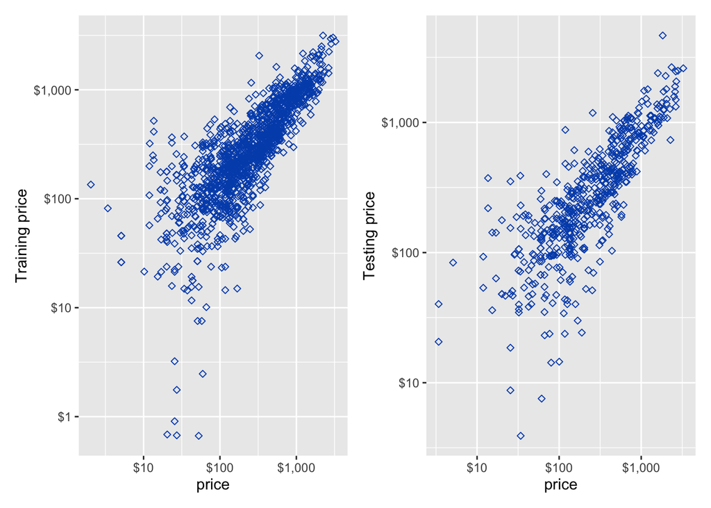

```r
model_train <- predict(lrmodel, training1) # simulate the situation in which we train model
model_test <- predict(lrmodel, testing1) # applying the training model
training_plot <- training1 %>%
  ggplot(aes(price, model_train)) +
  geom_point(col = '#0051BA', shape=23) +
  scale_x_log10(labels = dollar) +
  scale_y_log10(labels = dollar) +
  labs(y = "Training price")
testing_plot <- testing1 %>%
  ggplot(aes(price, model_test)) +
  geom_point(col = '#0051BA', shape=23) +
  scale_x_log10(labels = dollar) +
  scale_y_log10(labels = dollar) +
  labs(y = "Testing price")
(training_plot | testing_plot)
```

For the classification model the random forest package was used. Random forest is developed by aggregating trees, it can deal with a large number of features and helps to easily calculate factors’ importance.

Random forest models have a limitation of 53 categories. For this reason the first step in creating a random forest model is reducing the amount of factors. Twenty of the most numerous name collections will be used as a predictor, as well as category and type of size.

```r
tidyikea <- tidyikea %>%
  mutate(name = fct_lump(name, 20))
index2 <- createDataPartition(tidyikea$discounted, p = 0.7, list = FALSE)
training2 <- tidyikea[index2, ] # Training Set
testing2 <- tidyikea[-index2, ] # Test Set
rfmodel <- randomForest(discounted ~ name + category + size_type, data = training2)
rfmodel
```

```
##
## Call:
##  randomForest(formula = discounted ~ name + category + size_type,      data = training2)
##                Type of random forest: classification
##                      Number of trees: 500
## No. of variables tried at each split: 1
##
##         OOB estimate of  error rate: 12.26%
## Confusion matrix:
##       no yes class.error
## no  1074   5  0.00463392
## yes  158  93  0.62948207
```

In comparison to the caret package, random forest allows us to visualize the importance of factors in a very accessible way on a scale of 100. As was predicted in the visualization section, the name of the collection is the most defining coefficient of discounts, with category in second place and size being the least significant factor in determining whether the product will be discounted or not.

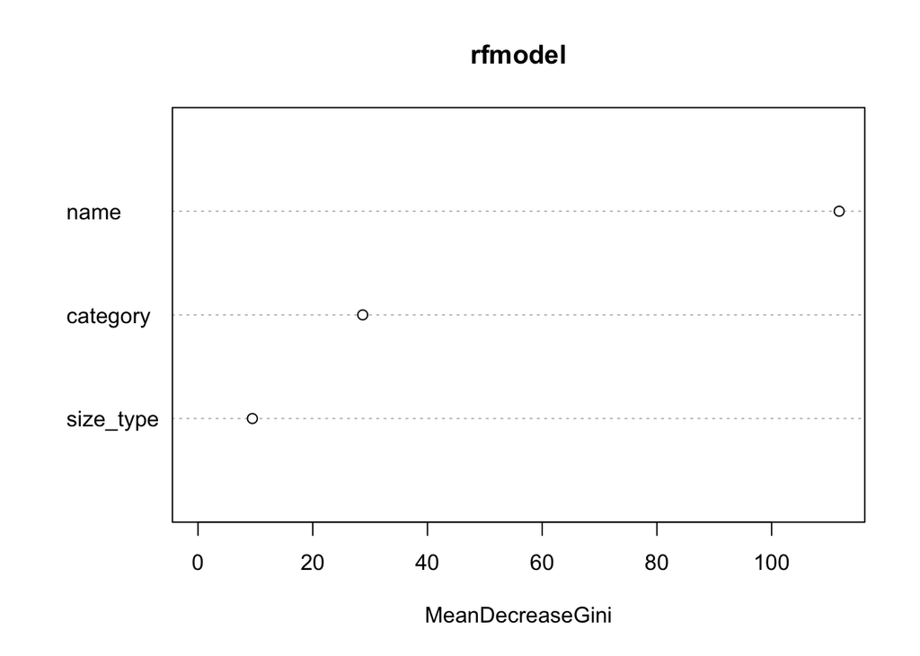

```r
varImpPlot(rfmodel, type = 2)
```

In the third model the output is category and coefficients are all other variables in the data frame. This classification model is an example of a low efficiency model. Accuracy of it is equal to only 53%, which means every second prediction will be incorrect. This situation is too complex to recreate with this type of model, therefore, this model is not valuable and does not have any application.

```r
index3 <- createDataPartition(tidyikea$category, p = 0.7, list = FALSE)
training3 <- tidyikea[index3, ] # Training Set
testing3 <- tidyikea[-index3, ] # Test Set
model3 <- train(category ~ ., data = training3,
                  method = "svmPoly",
                  preProcess = c("scale", "center"),
                  trControl = trainControl(method = "none"),
                  tuneGrid = data.frame(degree = 1, scale = 1, C = 1))
cat_pred <- predict(model3, testing3)
confusionMatrix(cat_pred, testing3$category)
```

```
## Confusion Matrix and Statistics
##
##                                       Reference
## Prediction                             Bar furniture Beds
##   Bar furniture                                    1    0
##   Beds                                             0    7
##   Bookcases & shelving units                       0    0
##   Cabinets & cupboards                             0    1
##   Café furniture                                   0    0
##   Chairs                                           6    0
##   Chests of drawers & drawer units                 0    1
##   Children's furniture                             0    0
##   Nursery furniture                                0    0
##   Outdoor furniture                                0    0
##   Room dividers                                    0    0
##   Sideboards, buffets & console tables             0    0
##   Sofas & armchairs                                0   12
##   Tables & desks                                   0    2
##   Trolleys                                         0    0
##   TV & media furniture                             0    0
##   Wardrobes                                        0    0
##                                       Reference
## Prediction                             Bookcases & shelving units
##   Bar furniture                                                 1
##   Beds                                                          0
##   Bookcases & shelving units                                   93
##   Cabinets & cupboards                                          6
##   Café furniture                                                0
##   Chairs                                                        0
##   Chests of drawers & drawer units                              2
##   Children's furniture                                          0
##   Nursery furniture                                             0
##   Outdoor furniture                                             0
##   Room dividers                                                 0
##   Sideboards, buffets & console tables                          0
##   Sofas & armchairs                                             0
##   Tables & desks                                                4
##   Trolleys                                                      0
##   TV & media furniture                                          6
##   Wardrobes                                                     0
```

[output cut: 222 more lines]

```
## Pos Pred Value                   NaN                     0.50000
## Neg Pred Value              0.996429                     0.97015
## Prevalence                  0.003571                     0.05000
## Detection Rate              0.000000                     0.02143
## Detection Prevalence        0.000000                     0.04286
## Balanced Accuracy           0.500000                     0.70301
##                      Class: Wardrobes
## Sensitivity                   0.79661
## Specificity                   0.99401
## Pos Pred Value                0.94000
## Neg Pred Value                0.97647
## Prevalence                    0.10536
## Detection Rate                0.08393
## Detection Prevalence          0.08929
## Balanced Accuracy             0.89531
```

### Performace and application

Models are “test beds” for ideas. Modelling allows for the virtual experiments, making it possible to test how things will operate before trying it out in reality. Models can “help us to visualize, predict, optimize, regulate and control complex systems” (Calder, 2021). Time, money and resources can be saved through applying modelling solutions to the fitting processes. According to an article “Computational modelling for decision-making”, there are several reasons why modelling is introduced in the business environment:

Thus, what is a possible application of a model for the IKEA furniture store? Firstly, estimating ROI of future projects. The model is necessary for writing a business plan, as it gives a more accurate depiction of possible sales and income. Furthermore, using the model can help calculate revenue and break even points for a new collection, by knowing its main characteristics.

Secondly, the current positioning of products. The pricing of IKEA products must be aligned with how they are positioned in the marketplace. For example, a new furniture line that is higher in price may not be received well by IKEA customers, whose preferences are affordable furniture.

Thirdly, distribution. Based on the customer preferences, IKEA can distribute furniture according to this data. The price model allows for predictions in what regions certain collections will or will not be present. IKEA is a company that is located world-wide. With a different level of consumer power between nations, certain furniture collections may not be present in all the stores.

However, in order for the model to be applicable to any business solutions, it needs to be accurate and efficient. The value of the model lies in its performance. The summary of the efficient model will include metrics like:

- the median, that is close to the zero;
- maximum and minimum that are equal in absolute values;
- coefficients, with no or very little t-values that are equal to zero and most of them are marked by asterisk;
- residual standard error (RSE), R-squared (R2) and the F-statistic all reflect the high correlation between coefficients and the outcome.

When it comes to linear regression models, the quality of the model’s performance can be evaluated through the three measurements in the model summary. They are residual standard error (RSE), R-squared (R2) and f-statistics.

```r
summary(lrmodel)
```

```
##
## Call:
## lm(formula = .outcome ~ ., data = dat)
##
## Residuals:
##      Min       1Q   Median       3Q      Max
## -1733.15   -95.73    -8.05    78.90  1227.23
##
## Coefficients:
##                                                Estimate Std. Error t value
## (Intercept)                                     409.592      6.035  67.872
## volume_cm3                                      357.477      7.740  46.185
## categoryBeds                                     75.003     12.565   5.969
## `categoryBookcases & shelving units`             -3.857     23.324  -0.165
## `categoryCabinets & cupboards`                   41.009     18.193   2.254
## `categoryCafé furniture`                          3.116      7.576   0.411
## categoryChairs                                   12.770     18.395   0.694
## `categoryChests of drawers & drawer units`       17.005     15.247   1.115
## `categoryChildren's furniture`                   -2.125     13.673  -0.155
## `categoryNursery furniture`                       1.702     12.055   0.141
## `categoryOutdoor furniture`                      24.383     12.857   1.896
## `categoryRoom dividers`                          -3.284      7.157  -0.459
## `categorySideboards, buffets & console tables`    7.321      7.966   0.919
## `categorySofas & armchairs`                      66.473     19.331   3.439
## `categoryTables & desks`                          2.865     14.291   0.200
## categoryTrolleys                                 10.695      7.244   1.476
## `categoryTV & media furniture`                    6.260     13.358   0.469
## categoryWardrobes                               -12.405     18.845  -0.658
## `designerMarcus Arvonen`                        -12.749      7.942  -1.605
## `designerCarina Bengs`                           -4.075      8.346  -0.488
## `designerK Hagberg M Hagberg`                   -55.670      9.361  -5.947
## `designerEhlén Johansson`                       -17.865     12.122  -1.474
## `designerFrancis Cayouette`                     -46.049      8.756  -5.259
## `designerOla Wihlborg`                          -32.627     10.980  -2.972
## `designerEva Lilja Löwenhielm`                   -5.765      8.146  -0.708
## `designerIKEA design`                           -93.329     16.045  -5.817
## `designerEbba Strandmark`                       -31.629      9.315  -3.395
## `designerTord Björklund`                        -32.303      8.531  -3.787
## `designerJon Karlsson`                          -44.523     11.146  -3.994
## `designerGillis Lundgren`                       -33.516      8.520  -3.934
```

[output cut: 30 more lines]

```
## `designerIKEA design`                          7.55e-09 ***
## `designerEbba Strandmark`                      0.000706 ***
## `designerTord Björklund`                       0.000160 ***
## `designerJon Karlsson`                         6.85e-05 ***
## `designerGillis Lundgren`                      8.80e-05 ***
## `designerCarl Öjerstam`                        0.005796 **
## `designerStudio Copenhagen`                    0.002264 **
## designerOther                                  2.34e-05 ***
## other_colorsyes                                0.003133 **
## ---
## Signif. codes:  0 '***' 0.001 '**' 0.01 '*' 0.05 '.' 0.1 ' ' 1
##
## Residual standard error: 220.1 on 1296 degrees of freedom
## Multiple R-squared:  0.7821, Adjusted R-squared:  0.7765
## F-statistic: 140.9 on 33 and 1296 DF,  p-value: < 2.2e-16
```

The R2 “the proportion of variation in the outcome variable that can be explained by the model predictor variables” (Linear Regression Essentials in R - Articles - STHDA, 2021). Opposite to RSE, high R2 reflects better model performance. The closer R2 is to 1, the more variability of the data frame is explained by the linear regression. If the R2 is closer to 0, consecutively, the model can not explain the outcome through the model coefficients. In the IKEA data set if R2 is equal to 0.78, that is an average outcome that leans more towards the higher performance output.

F-statistics is a metric of an overall efficiency of the model, it is an overview of the t-value. It signifies that at least one coefficient is not equal to zero. In the current model there are 17 coefficients that do not equal zero.

The main application of the model is making predictions. As an example, IKEA releases two new products: both are beds, but the first one is half the size of the other, doesn’t have a designer or additional colorways. According to the predicted prices, the first bed will be almost half the price of a second one.

```r
newfurniture <- data.frame(volume_cm3 = c(100000,  200000),
                           category = c("Beds","Beds"),
                           designer = c("IKEA design","Henrik Preutz"),
                           other_colors = c("no", "yes"))
lrmodel %>% predict(newfurniture)
```

```
##        1        2
## 370.7606 672.1211
```

```r
disc_pred <- predict(rfmodel, testing2)
confusionMatrix(disc_pred, testing2$discounted)
```

```
## Confusion Matrix and Statistics
##
##           Reference
## Prediction  no yes
##        no  461  70
##        yes   1  37
##
##                Accuracy : 0.8752
##                  95% CI : (0.8452, 0.9012)
##     No Information Rate : 0.812
##     P-Value [Acc > NIR] : 3.315e-05
##
##                   Kappa : 0.4568
##
##  Mcnemar's Test P-Value : 7.023e-16
##
##             Sensitivity : 0.9978
##             Specificity : 0.3458
##          Pos Pred Value : 0.8682
##          Neg Pred Value : 0.9737
##              Prevalence : 0.8120
##          Detection Rate : 0.8102
##    Detection Prevalence : 0.9332
##       Balanced Accuracy : 0.6718
##
##        'Positive' Class : no
##
```

### Conclusion

The report findings can be summarized as:

- Data cleaning and wrangling that included removing and omitting unuseful data, coercion, fixing values in the necessary column, adding new variables for following analysis.
- Data visualisation of the data set. Seven plots were created to analyze the relationship between data variables and to draw conclusions of what trends and patterns can be seen in IKEA furniture data.
- Creating one linear regression and two classification models. Analysing the summary of the created models and describing the importance of coefficients.
- Model application, elaborating on how created models can be applied to a business scenario and why it is important.
- Model performance, evaluates how accurate and applicable to the real scenario the model is. After performance is completed analysis it was distinguished that category classification was not accurate or efficient, whereas two other models have high performance and could be applied in a business scenario.

### References

Boehmke, P., 2016. Data Wrangling with R. Cham: Springer International Publishing. Calder, M., 2021. Computational modelling for decision-making: where, why, what, who and how | Royal Society Open Science. [online] Royalsocietypublishing.org. Available at: https://royalsocietypublishing.org/doi/10.1098/rsos.172096 [Accessed 17 June 2021]. de Jonge, E. and van der Loo, M., 2021. An introduction to data cleaning with R. [online] Cran.r-project.org. Available at: https://cran.r-project.org/doc/contrib/de_Jonge+van_der_Loo-Introduction_to_data_cleaning_with_R.pdf [Accessed 17 June 2021]. Sthda.com. 2021. Linear Regression Essentials in R - Articles - STHDA. [online] Available at: http://www.sthda.com/english/articles/40-regression-analysis/165-linear-regression-essentials-in-r/ [Accessed 17 June 2021]. Toomey, D., n.d. R for data science. Waring, E., 2021. Compact and Flexible Summaries of Data. [online] Cran.r-project.org. Available at: https://cran.r-project.org/web/packages/skimr/skimr.pdf [Accessed 17 June 2021].